# **Modelos de regresión para precios de viviendas en Boston**

# **Entendimiento de los datos**

## **1. Adquisición de datos**

```python
!pip install -U scikit-learn

import sklearn
```

```python
import numpy as np
import pandas as pd

from sklearn.linear_model import LinearRegression
from sklearn.tree import DecisionTreeRegressor, plot_tree
from sklearn.neighbors import KNeighborsRegressor

from sklearn.model_selection import train_test_split

import matplotlib as mpl
import matplotlib.pyplot as plt

# Configuraciones de Matplotlib
%matplotlib inline
plt.rcParams['figure.dpi'] = 110
```

Este material se realizó con las siguientes versiones:

- **`Python`**: 3.10.12
- **`Numpy`**: 1.23.5
- **`Pandas`**: 1.5.3
- **`Scikit-learn`**: 1.3.0
- **`Matplotlib`**: 3.7.1

```python
!python --version
print('Numpy', np.__version__)
print('Pandas', pd.__version__)
print('Scikit-learn', sklearn.__version__)
print('Matplotlib', mpl.__version__)
```

```
Python 3.10.12
Numpy 1.23.5
Pandas 1.5.3
Scikit-learn 1.3.0
Matplotlib 3.7.1
```

Para este caso de estudio se utilizará el conjunto de datos [Boston Housing](https://www.kaggle.com/datasets/schirmerchad/bostonhoustingmlnd) (con algunos datos eliminados) disponible en *Kaggle* y proveniente del *Repositorio de Aprendizaje Automático de la Universidad de California en Irvine*. También se encuentra disponible en los conjuntos de datos de la librería *Scikit-Learn*.

```python
housing = pd.read_csv("HousingData.csv")
```

## **2. Análisis exploratorio de datos**

### **2.1. Descripciones y selección de características**

Se seleccionan algunos datos de la tabla para adquirir un **`entendimiento general`** de la composición de las filas.

```python
housing.head()
```

|  | Unnamed: 0 | CRIM | ZN | INDUS | CHAS | NOX | RM | AGE | DIS | RAD | TAX | PTRATIO | LSTAT | MEDV |
| --- | --- | --- | --- | --- | --- | --- | --- | --- | --- | --- | --- | --- | --- | --- |
| 0 | 0 | 0.00632 | 18.0 | 2.31 | 0.0 | 0.538 | 6.575 | 65.2 | 4.0900 | 1 | 296 | 15.3 | 4.98 | 24.0 |
| 1 | 1 | 0.02731 | 0.0 | 7.07 | 0.0 | 0.469 | 6.421 | 78.9 | 4.9671 | 2 | 242 | 17.8 | 9.14 | 21.6 |
| 2 | 2 | 0.02729 | 0.0 | 7.07 | 0.0 | 0.469 | 7.185 | 61.1 | 4.9671 | 2 | 242 | 17.8 | 4.03 | 34.7 |
| 3 | 3 | 0.03237 | 0.0 | 2.18 | 0.0 | 0.458 | 6.998 | 45.8 | 6.0622 | 3 | 222 | 18.7 | 2.94 | 33.4 |
| 4 | 4 | 0.06905 | 0.0 | 2.18 | 0.0 | 0.458 | 7.147 | 54.2 | 6.0622 | 3 | 222 | 18.7 | NaN | 36.2 |

Con esta vista premilinar se identifica una columna que no aporta **`información relevante`** para el análisis que se busca realizar. Por esto, se elimina a continuación:

```python
housing = housing.drop(columns=["Unnamed: 0"])
```

Con esto, se revisa la **`información general`** del conjunto de datos y se puede detallar que todas las columnas tienen un formato numérico, por lo que ya están listas para el análisis de regresión. Además, se hace la anotación de que la variable que se busca describir es **`MEDV`** (mediana de los valores de las casas ocupadas por sus dueños).

```python
housing.info()
```

```
<class 'pandas.core.frame.DataFrame'>
RangeIndex: 506 entries, 0 to 505
Data columns (total 13 columns):
 #   Column   Non-Null Count  Dtype
---  ------   --------------  -----
 0   CRIM     486 non-null    float64
 1   ZN       486 non-null    float64
 2   INDUS    486 non-null    float64
 3   CHAS     486 non-null    float64
 4   NOX      506 non-null    float64
 5   RM       506 non-null    float64
 6   AGE      486 non-null    float64
 7   DIS      506 non-null    float64
 8   RAD      506 non-null    int64
 9   TAX      506 non-null    int64
 10  PTRATIO  506 non-null    float64
 11  LSTAT    486 non-null    float64
 12  MEDV     506 non-null    float64
dtypes: float64(11), int64(2)
memory usage: 51.5 KB
```

# **Preparación de los datos**

## **1. Limpieza de datos**

Por medio del método **`info`** se identificó que seis de los parámetros poseen valores nulos o faltantes.

Entre estas columnas se tendrían 120 **`entradas incompletas`** como máximo (alrededor del 24% de los datos totales). Así pues, es posible que al eliminar estas filas se afecte el conjunto de datos de alguna manera. Sin embargo, no es del todo necesario mantener la distribución de los datos originales para la finalidad de este estudio.

```python
housing = housing.dropna()
```

## **2. Nuevos datos preparados**

Se selecciona una **`muestra aleatoria`** de la tabla para verificar el efecto de los cambios realizados.

```python
housing.sample(3)
```

|  | CRIM | ZN | INDUS | CHAS | NOX | RM | AGE | DIS | RAD | TAX | PTRATIO | LSTAT | MEDV |
| --- | --- | --- | --- | --- | --- | --- | --- | --- | --- | --- | --- | --- | --- |
| 54 | 0.01360 | 75.0 | 4.00 | 0.0 | 0.410 | 5.888 | 47.6 | 7.3197 | 3 | 469 | 21.1 | 14.80 | 18.9 |
| 374 | 18.49820 | 0.0 | 18.10 | 0.0 | 0.668 | 4.138 | 100.0 | 1.1370 | 24 | 666 | 20.2 | 37.97 | 13.8 |
| 49 | 0.21977 | 0.0 | 6.91 | 0.0 | 0.448 | 5.602 | 62.0 | 6.0877 | 3 | 233 | 17.9 | 16.20 | 19.4 |

De nuevo, se revisa la **`información general`** del conjunto de datos. Ahora no hay valores faltantes en la tabla.

```python
housing.info()
```

```
<class 'pandas.core.frame.DataFrame'>
Int64Index: 394 entries, 0 to 504
Data columns (total 13 columns):
 #   Column   Non-Null Count  Dtype
---  ------   --------------  -----
 0   CRIM     394 non-null    float64
 1   ZN       394 non-null    float64
 2   INDUS    394 non-null    float64
 3   CHAS     394 non-null    float64
 4   NOX      394 non-null    float64
 5   RM       394 non-null    float64
 6   AGE      394 non-null    float64
 7   DIS      394 non-null    float64
 8   RAD      394 non-null    int64
 9   TAX      394 non-null    int64
 10  PTRATIO  394 non-null    float64
 11  LSTAT    394 non-null    float64
 12  MEDV     394 non-null    float64
dtypes: float64(11), int64(2)
memory usage: 43.1 KB
```

Con una **`descripción estadística básica`** muy general sobre las columnas de la tabla se identifica el comportamiento de los atributos a tener en cuenta en el presente estudio. También es posible distinguir el **`rango`** que toma cada variable del conjunto.

```python
housing.describe()
```

|  | CRIM | ZN | INDUS | CHAS | NOX | RM | AGE | DIS | RAD | TAX | PTRATIO | LSTAT | MEDV |
| --- | --- | --- | --- | --- | --- | --- | --- | --- | --- | --- | --- | --- | --- |
| count | 394.000000 | 394.000000 | 394.000000 | 394.000000 | 394.000000 | 394.000000 | 394.000000 | 394.000000 | 394.000000 | 394.000000 | 394.000000 | 394.000000 | 394.000000 |
| mean | 3.690136 | 11.460660 | 11.000863 | 0.068528 | 0.553215 | 6.280015 | 68.932741 | 3.805268 | 9.403553 | 406.431472 | 18.537563 | 12.769112 | 22.359645 |
| std | 9.202423 | 23.954082 | 6.908364 | 0.252971 | 0.113112 | 0.697985 | 27.888705 | 2.098571 | 8.633451 | 168.312419 | 2.166460 | 7.308430 | 9.142979 |
| min | 0.006320 | 0.000000 | 0.460000 | 0.000000 | 0.389000 | 3.561000 | 2.900000 | 1.129600 | 1.000000 | 187.000000 | 12.600000 | 1.730000 | 5.000000 |
| 25% | 0.081955 | 0.000000 | 5.130000 | 0.000000 | 0.453000 | 5.879250 | 45.475000 | 2.110100 | 4.000000 | 280.250000 | 17.400000 | 7.125000 | 16.800000 |
| 50% | 0.268880 | 0.000000 | 8.560000 | 0.000000 | 0.538000 | 6.201500 | 77.700000 | 3.199200 | 5.000000 | 330.000000 | 19.100000 | 11.300000 | 21.050000 |
| 75% | 3.435973 | 12.500000 | 18.100000 | 0.000000 | 0.624000 | 6.605500 | 94.250000 | 5.116700 | 24.000000 | 666.000000 | 20.200000 | 17.117500 | 25.000000 |
| max | 88.976200 | 100.000000 | 27.740000 | 1.000000 | 0.871000 | 8.780000 | 100.000000 | 12.126500 | 24.000000 | 711.000000 | 22.000000 | 37.970000 | 50.000000 |

# **Modelamiento**

## **1. Partición de registros**

Se genera la **`división`** entre la matriz de ejemplos y el vector de etiquetas objetivo.

```python
X = housing.drop(columns=["MEDV"])
y = housing["MEDV"].values
```

También se separan los datos de **`entrenamiento`** de los ejemplos con los que, posteriormente, se estimará el desempeño del modelo. Para esto se usará el **25%** de los registros en la evaluación de **`prueba`**.

```python
X_train, X_test, y_train, y_test = train_test_split(X, y, test_size=0.25, random_state=42)
```

## **2. Regresión lineal**

### **2.1. Entrenamiento**

Primero, se utiliza un modelo de **`regresión lineal`** para intentar predecir los valores de la variable **`MEDV`**.

```python
model = LinearRegression()
model.fit(X_train, y_train)
```

```
LinearRegression()
```

Al extraer los **`coeficientes`** de la función de regresión calculada, se identifican los atributos del conjunto de datos que influyen en mayor medida en el resultado. Entre estos se encuentran las variables:

- CHAS
- NOX
- RM
- DIS

```python
list(model.coef_)
```

```
[-0.12640206869663093,
 0.04865096258353939,
 0.008644126207700456,
 1.6277740191718688,
 -18.14809661213014,
 3.8358183256549743,
 -0.021863085879548168,
 -1.5100027405932095,
 0.2433943198185034,
 -0.01431367839914538,
 -0.8963326427211923,
 -0.39592607525694584]
```

### **2.2. Evaluación de desempeño**

```python
model.score(X_test, y_test)
```

```
0.6796310160586931
```

## **3. Árbol de regresión**

### **3.1. Entrenamiento y selección**

Ahora se utilizará el método de **`árboles de regresión`**. Además, el modelo se evaluará con distintos valores en parámetros como la cantidad máxima de hojas y la profundidad máxima.

```python
parameters = {"max_leaf_nodes": [10, 15, 20, 25],
              "max_depth": [5, 6, 7, 8, 9]
              }
```

Luego de entrenar y evaluar los distintos árboles, se mantiene el modelo que demuestra un **`mayor coeficiente de determinación`**.

```python
best = [0, None, 0, 0]
for i in parameters["max_leaf_nodes"]:
    for j in parameters["max_depth"]:
        model = DecisionTreeRegressor(max_leaf_nodes=i, max_depth=j, random_state=42)
        model.fit(X_train, y_train)
        score = model.score(X_test, y_test)
        if score > best[0]:
            best = [score, model, i, j]
model = best[1]
```

### **3.2. Evaluación de desempeño**

```python
model.score(X_test, y_test)
```

```
0.7379318726850115
```

### **3.3. Visualización**

Se muestra el árbol generado con un nivel de profundidad de 6 y con 20 hojas. En este caso, los **`atributos más importantes`** al momento de aproximar el valor de las viviendas son:

- RM
- LSTAT
- CRIM
- INDUS
- NOX
- TAX
- PTRATIO
- AGE

Nótese que dos de estas características también se tuvieron en cuenta para el primer modelo revisado, a saber, **`RM`** y **`NOX`**.

Otro aspecto que cabe resaltar es que, en general, se utilizan muchas variables para hacer predicciones eficientes con árboles; sólo faltaron cuatro (**`ZN`**, **`CHAS`**, **`DIS`** y **`RAD`**).

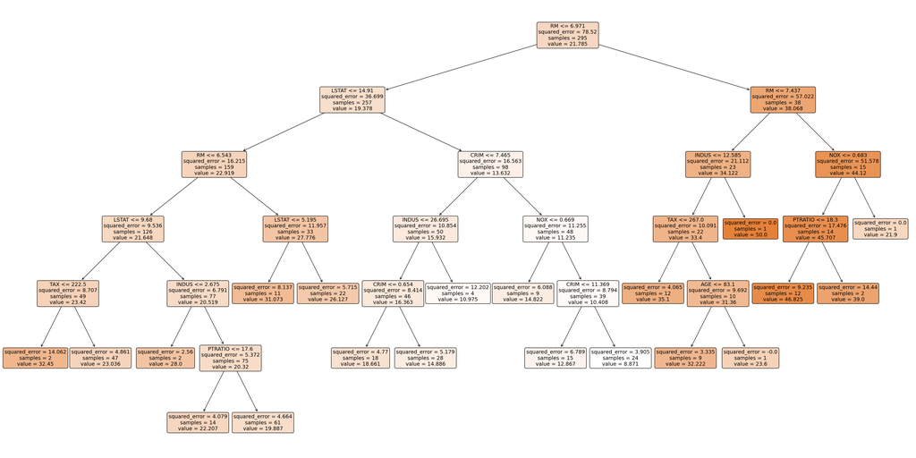

```python
plt.figure(figsize=(40,20))
plot_tree(model, filled=True, rounded=True, feature_names=list(X.columns))
plt.show()
```

## **4. K vecinos más cercanos**

### **4.1. Entrenamiento y selección**

Por último, se entrena un **`modelo KNN`** utilizando diferentes valores para el parámetro K (número de puntos vecinos para tomar una decisión).

```python
k_value = 100
```

Al igual que con los árboles, se mantiene el modelo que maximiza el **`coeficiente de determinación`**.

```python
best = [0, None, 0]
for k in range(1, k_value + 1):
    model = KNeighborsRegressor(n_neighbors=k, weights="distance")
    model.fit(X_train, y_train)
    score = model.score(X_test, y_test)
    if score > best[0]:
        best = [score, model, k]
model = best[1]
```

### **4.2. Evaluación de desempeño**

```python
model.score(X_test, y_test)
```

```
0.46095814302247384
```

# **Análisis de resultados**

Finalmente se encontró que el modelo entrenado por medio de un **`árbol de regresión`** obtuvo el mejor desempeño al describir la variable objetivo (**`MEDV`**), ya que se obtuvo un valor del $74\%$ para la métrica utilizada.

El desempeño del algoritmo de **`KNN`** ($46\%$) podría explicarse porque los datos utilizados se encuentran muy dispersos sobre los rangos de todas las variables y no forman núcleos o grupos bien definidos, resultando en un modelo entrenado que no logró obtener **`rendimientos`** de prueba satisfactorios.

Además, el conjunto de datos no tuvo características lo suficientemente **`correlacionadas`** como para aportar de forma significativa al desempeño del modelo de **`regresión lineal`** ($68\%$). Aun así, se obtuvieron resultados bastante decentes.

# **Referencias**

- [Kaggle - Boston Housing](https://www.kaggle.com/datasets/schirmerchad/bostonhoustingmlnd)
- [ScikitLearn - API Reference](https://scikit-learn.org/stable/modules/classes.html#)

# **Créditos**

- Samuel David Moreno Vahos